# Assignment 9 Part II

Learning Group 3 - Meka McCammon, Joy Li, Anna Ehrhorn, and Genee Glascoe

April 11, 2020

This is a study investigated the following research question: *For women who* *suffered childhood physical abuse, is a difference in the average PTSD scores* *of women who also suffered childhood sexual abuse and those who did not suffer* *childhood sexual abuse, after accounting for the severity of the childhood* *physical abuse?*

### Question 1

Side-by-side boxplots that show differences in PTSD scores of women who suffered childhood sexual abuse compared to those who did not suffer from childhood sexual abuse.

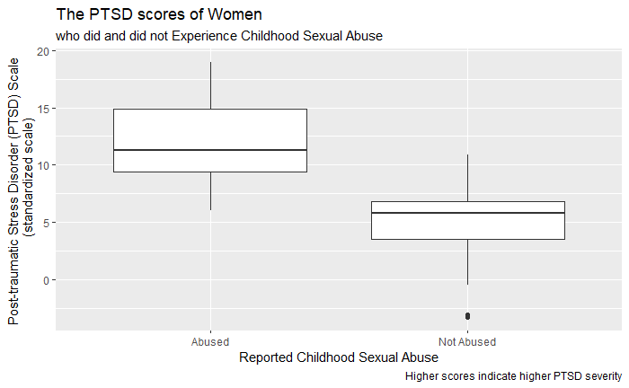

```r
ggplot(data = abuse.data) +
  geom_boxplot(mapping = aes(x = csa, y = ptsd)) +
  labs(x = "Reported Childhood Sexual Abuse", y = "Post-traumatic Stress Disorder (PTSD) Scale
       (standardized scale)",
       title = "The PTSD scores of Women",
       subtitle = "who did and did not Experience Childhood Sexual Abuse",
       caption = "Higher scores indicate higher PTSD severity") +
  scale_x_discrete(labels = c('Abused','Not Abused'))
```

### Question 2

Calculated descriptive statistics for PTSD scores of women who suffered childhood sexual abuse compared to those who did not suffer from childhood sexual abuse.

```r
tapply(abuse.data$ptsd, abuse.data$csa, summary)
```

```
$Abused
   Min. 1st Qu.  Median    Mean 3rd Qu.    Max.
  5.985   9.374  11.313  11.941  14.901  18.993

$`Not Abused`
   Min. 1st Qu.  Median    Mean 3rd Qu.    Max.
 -3.349   3.544   5.794   4.696   6.838  10.914
```

```r
tapply(abuse.data$ptsd, abuse.data$csa, sd)
```

```
    Abused Not Abused
  3.440152   3.519743
```

### Question 3

Side-by-side boxplots showing the relationship of Childhood Physical Abuse (the covariate) for women who suffered childhood sexual abuse to those who did not suffer childhood sexual abuse (the explanatory variable).

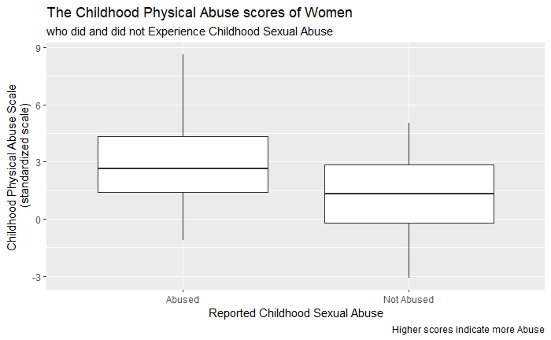

```r
ggplot(data = abuse.data) +
  geom_boxplot(mapping = aes(x = csa, y = cpa)) +
  labs(x = "Reported Childhood Sexual Abuse", y = "Childhood Physical Abuse Scale
       (standardized scale)",
       title = "The Childhood Physical Abuse scores of Women",
       subtitle = "who did and did not Experience Childhood Sexual Abuse",
       caption = "Higher scores indicate more Abuse") +
  scale_x_discrete(labels = c('Abused','Not Abused'))
```

### Question 4

A five-number summary and standard deviations for Childhood Phyical Abuse Scores (the covariate) for women who suffered childhood sexual abuse to those who did not suffer childhood sexual abuse (the explanatory variable).

```r
tapply(abuse.data$cpa, abuse.data$csa, summary)
```

```
$Abused
   Min. 1st Qu.  Median    Mean 3rd Qu.    Max.
 -1.115   1.415   2.627   3.075   4.317   8.647

$`Not Abused`
   Min. 1st Qu.  Median    Mean 3rd Qu.    Max.
-3.1204 -0.2299  1.3216  1.3088  2.8309  5.0497
```

```r
tapply(abuse.data$cpa, abuse.data$csa, sd)
```

```
    Abused Not Abused
  2.371215   1.970577
```

### Question 5

This plot shows the difference in PTSD scores for women who were and were not sexually abused while taking into account childhood physical abuse, and tests for interaction.

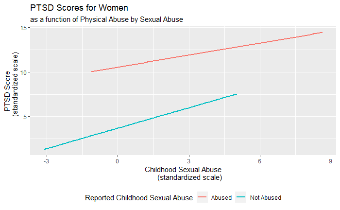

```r
ggplot(abuse.data, aes(x = cpa, y = ptsd, color = csa))+
  stat_smooth (method = "lm", se = FALSE)+
  theme(legend.position = "right")+
  labs(x = "Childhood Sexual Abuse
       (standardized scale)",
       y = "PTSD Score
       (standardized scale)",
       title = "PTSD Scores for Women",
       subtitle = "as a function of Physical Abuse by Sexual Abuse",
       color = "Reported Childhood Sexual Abuse") +
  theme(legend.position = "bottom") +
  scale_color_discrete(labels = c('Abused','Not Abused'))
```

### Question 6

```r
model1=lm(data=abuse.data, formula= cpa ~ ptsd)
summary(model1)
```

```
Call:
lm(formula = cpa ~ ptsd, data = abuse.data)

Residuals:
    Min      1Q  Median      3Q     Max
-4.4328 -1.4451 -0.0805  1.4451  4.1565

Coefficients:
            Estimate Std. Error t value Pr(>|t|)
(Intercept)   0.2474     0.4943   0.500    0.618
ptsd          0.2345     0.0482   4.865 6.27e-06 ***
---
Signif. codes:  0 ‘***’ 0.001 ‘**’ 0.01 ‘*’ 0.05 ‘.’ 0.1 ‘ ’ 1

Residual standard error: 2.077 on 74 degrees of freedom
Multiple R-squared:  0.2424,    Adjusted R-squared:  0.2321
F-statistic: 23.67 on 1 and 74 DF,  p-value: 6.272e-06
```

```r
abuse.data$predicted <- predict(model1)   # Save the predicted values
abuse.data$residuals <- residuals(model1) # Save the residual values
abuse.data %>% select(cpa, predicted, residuals) %>% head()
```

| cpa | predicted | residuals |
| --- | --- | --- |
| 2.04786 | 2.525406 | -0.4775460 |
| 0.83895 | 1.694198 | -0.8552479 |
| -0.24139 | 3.802502 | -4.0438915 |
| -1.11461 | 2.900429 | -4.0150390 |
| 2.01468 | 2.581735 | -0.5670550 |
| 6.71131 | 2.554765 | 4.1565446 |

Plotted the residuals as a function of the predicted values to confirm homogeneity of variance.

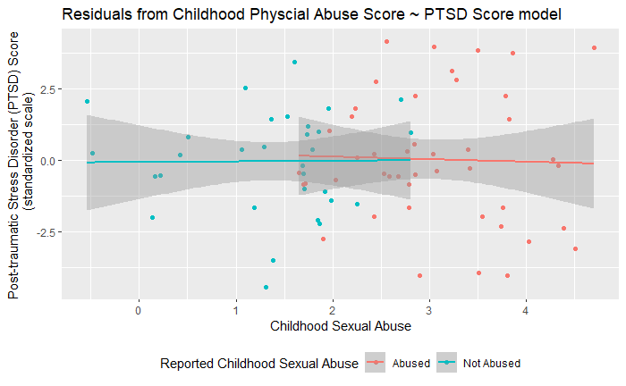

```r
ggplot(data=abuse.data, aes(x=predicted, y=residuals, color = csa))+
  geom_point()+
  geom_smooth(method="lm")+
  labs(x = "Childhood Sexual Abuse",
       y = "Post-traumatic Stress Disorder (PTSD) Score
       (standardized scale)",
       title = "Residuals from Childhood Physcial Abuse Score ~ PTSD Score model",
       color = "Reported Childhood Sexual Abuse") +
  theme(legend.position = "bottom") +
  scale_color_discrete(labels = c('Abused','Not Abused'))
```

### Question 7

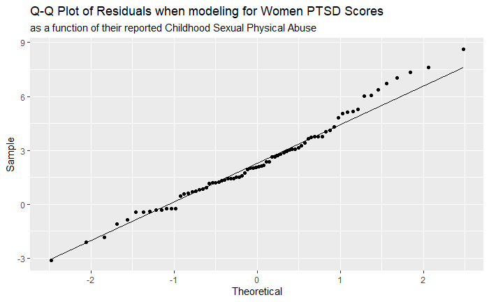

```r
abuse.data$residuals <- residuals(model1)

ggplot(data = abuse.data, x = csa, y = ptsd) +
  geom_qq(aes(sample = cpa)) +
  stat_qq(aes(sample = cpa)) +
  stat_qq_line(aes(sample = cpa)) +
  labs(x = "Theoretical", y = "Sample",
       title = "Q-Q Plot of Residuals when modeling for Women PTSD Scores",
       subtitle = "as a function of their reported Childhood Sexual Physical Abuse")
```

### Question 8

A scatterplot illustrating the relationship of women who suffered childhood sexual abuse to those who did not suffer childhood sexual abuse (the explanatory variable) to their PTSD Scores (the response variable) after accounting for their Childhood Physical Abuse Score (the covariate).

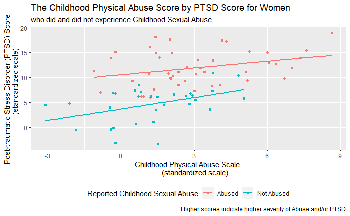

```r
library(tidyverse)
ggplot(abuse.data, aes(x = cpa, y = ptsd, color = csa)) +
  geom_point() +
  stat_smooth(method = "lm", se = FALSE) +
  labs(x = "Childhood Physical Abuse Scale
       (standardized scale)",
       y = "Post-traumatic Stress Disorder (PTSD) Score
       (standardized scale)",
       title = "The Childhood Physical Abuse Score by PTSD Score for Women ",
       subtitle = "who did and did not experience Childhood Sexual Abuse",
       caption = "Higher scores indicate higher severity of Abuse and/or PTSD",
       color = "Reported Childhood Sexual Abuse") +
  theme(legend.position = "bottom") +
  scale_color_discrete(labels = c('Abused','Not Abused'))
```

### Question 9

The constructed ANCOVA table after modeling the women’s PTSD Scores (the response variable) as a function for the women who suffered childhood sexual abuse to those who did not suffer childhood sexual abuse (the explanatory variable) and the amount of childhood physical abuse (the covariate - without interaction).

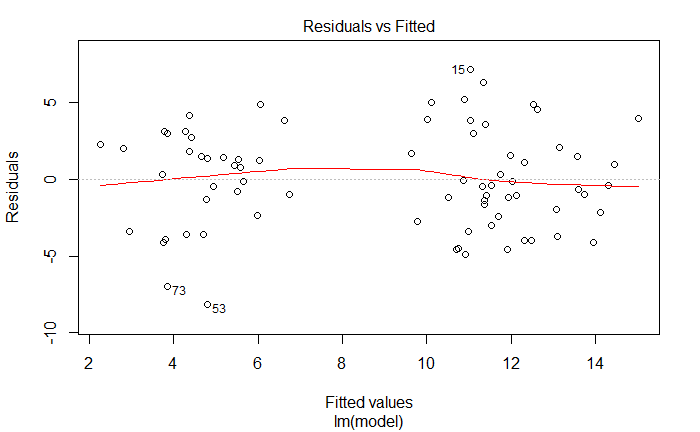

```r
model <- abuse.data$ptsd ~ abuse.data$cpa + abuse.data$csa
model.out <- lm(model)
plot(model.out, 1)
```

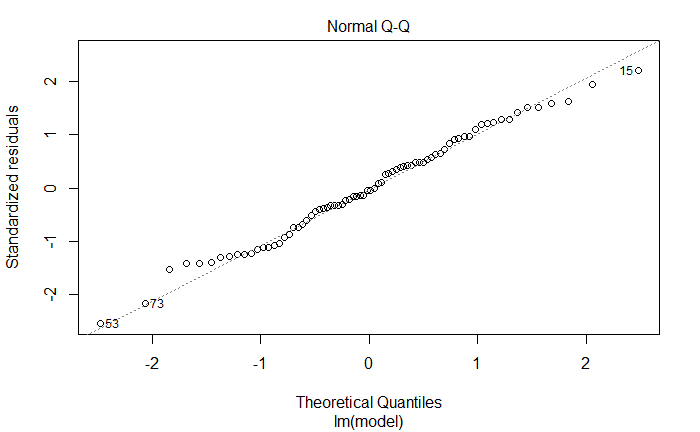

```r
plot(model.out, 2)
```

```r
anova(model.out)
```

```
Analysis of Variance Table

Response: abuse.data$ptsd
               Df Sum Sq Mean Sq F value    Pr(>F)
abuse.data$cpa  1 449.80  449.80  41.984 9.462e-09 ***
abuse.data$csa  1 624.03  624.03  58.247 6.907e-11 ***
Residuals      73 782.08   10.71
---
Signif. codes:  0 ‘***’ 0.001 ‘**’ 0.01 ‘*’ 0.05 ‘.’ 0.1 ‘ ’ 1
```

```r
model.out
```

```
Call:
lm(formula = model)

Coefficients:
             (Intercept)            abuse.data$cpa  abuse.data$csaNot Abused
                 10.2480                    0.5506                   -6.2728
```